# 第一章：机器学习导论

## 1. 1 预测房价的数学模型

1. 机器学习步骤：模型假设->学习、训练、拟合->预测

   本练习假设房价与房屋的面积为线性关系：y=kx+b

### 线性模型代码示例

```python
class LinearModel:

    def __init__(self):
        self.pmega = 0
        self.b = 0

    def fit(self,x_train,y_train):
        self.omega = (y_train[0]-y_train[1]) / (x_train[0] - x_train[1])
        self.b = y_train[0] - x_train[0]*self.omega
        return

    def predict(self,x_test):
        y_test = self.omega * x_test + self.b
        return y_test
```

```python
def main():
    s = input("input x1 y1 x2 y2:")
    sList = s.split()
    X = []; Y = [];
    X.append(eval(sList[0])); Y.append(eval(sList[1]))
    X.append(eval(sList[2])); Y.append(eval(sList[3]))

    lm = LinearModel()
    lm.fit(X,Y)
    print("Training result:omega = ",lm.omega,",b = " ,lm.b,"\n")

    x = eval(input("Input x:"));
    y = lm.predict(x)
    print("Pridict result: x = ", x, "平米, y = ", y ,"万元")
```

```python
main()
```

```
Training result:omega =  2.0 ,b =  0.0
```

```
Pridict result: x =  80 平米, y =  160.0 万元
```

## 1. 2 随机模型机器学习算法

1. 样本数据存在随机的观测误差，则并非上一节那么理想
2. 采集一组数据，m个数据点。这组数据叫样本或样本集，m叫做样本容量
3. f(x;w,b) = wx + b ,根据这组数据选择最佳的w和b，称为最佳参数
4. 选择最优模型的方法：a.最小二乘法 b.极大似然估计
5. 经典的数据分析方法：回归分析

### 1.2.1 最小二乘法

1. 所谓的损失函数就是样本集所有样本点误差之和
2. 不同的损失函数，实际上是误差定义的方式不同
3. 最小二乘法在选择误差时选择的是(yi-f(x,theta))^2
4. 采用平方形式的误差，损失函数为实数集上的凸函数，凸函数之和为凸函数。凸函数存在唯一的极值点，且是最小值点。因此可以用微积分中求极值的方法进行最小化求解。

### 1.2.2 极大似然估计

1. 为随机模型，$Y=f(X)+ \varepsilon$
2. 获得x出现时y出现的概率密度函数$p(y|x)$ ，含f(x)的参数$\theta$
3. 根据样本集中的各点(xi,yi),写出每个点出现的概率$pi = p(yi|xi)$,并相乘，就是这个点集出现的概率
4. 使得点击出现概率最大的$\theta$便是最优的参数

## 1. 3 随机变量与数学语言

### 1.3.1 随机变量

1. 观测过程存在误差，故将随机性引入机器学习模型
2. 合并次要因素以简化模型,不重要的参数可以合并为一个参数。理论依据：中心极限定理，许多小影响的独立随机因素带来的总影响可看作一个近似服从正态分布的随机变量。
3. 研究总体的规律需要使用随机模型。

### 1.3.2 随机变量应用举例

1. 随机函数：一组形式相同但是参数不同的函数的集合。
2. 其应用：房屋市场价的随机性可以认为是因房屋中介公司使用的报价模型不一样

### 1.3.3 数学语言

1. 凸函数琴生不等式：f(E(X))≤E（f(X)）
2. 凸函数：定义。凸函数上任意两点的割线位于函数图形的正上方。
3. 凸集：任意两点线段上的点仍属于D
4. 凹函数琴生不等式：f(E(X))≥E（f(X)

## 1. 4 更加复杂的数学模型

### 1.4.1 数学形式未知的模型

1. 模型假设对机器学习至关重要，模型假设错误则后续工作变得毫无意义。
2. 科学的建模方法：数据可视化建模、数学建模

### 1.4.2 多元模型

1. 由多元函数表示的模型就是多元模型
2. 这么多个自变量就叫特征或模型的输入，因变量就叫预测目标或模型输出
3. 机器学习通常使用向量兴化市表示多元模型，叫特征向量，特征向量所包含的特征项的个数就叫做维度
4. 列向量作为向量的原始形式，用向量转置作为横向量。

### 1.4.3 用矩阵描述问题及算法过程

主要是介绍了用矩阵描述损失函数并对其求导获得最优参数的过程。 其中涉及了一些数学推导，有兴趣可以之后再草稿纸上推导。

## 1.5 机器学习问题

### （1）三种机器学习问题

1. 回归问题：根据样本数据建立y与x之间的关系，y为连续值
2. 分类问题：与回归问题类似，y为离散值
3. 聚类问题：与分类问题类似，唯一区别是样本数据集里面没有类别标注yi，无监督学习。

### （2）机器学习教学三个层面

1. 模型设计层面：提出新模型、新算法
2. 模型变成方面：人家给了算法，你编程实现
3. 应用编程方面：用人家写好的程序解决问题

# 第二章：回归问题

## 2.1 编程环境与数据集

### 2.1.1 编程环境

1. NumPy、Panda、Matplotlib
2. scikit-learn：机器学习类库
3. Anavaconda:IDE集成开发环境

### 2.2.2 数据集

（1）练习数据获取方式

scikit-learn库sklearn.datasets模块中的load_*()、fetch_()、make_*()可以调用、下载并保存、生成一些数据

（2）代码文件和数据集文件管理

1. 建立一个文件专门存机器学习相关文件
2. 在该文件夹下建立一个data文件夹用于存数据文件

（3）下载数据集示例

原始示例代码，运行之后报错，原因是load_boston已被官方删除，如需学习使用，直接用链接下载

```python
# import numpy as np
# import pandas as pd
# import matplotlib.pyplot as plt
# %matplotlib inline

# #下载波士顿房价数据集，保存到本地文件boston.csv中
# from sklearn.datasets import load_boston
# house = load_boston()
# print(house.data.shape)

# df = pd.DataFrame(house.data, columns=house.feature_names)
# df['MEDV'] = house['target']
# df.to_csv("./data/boston.csv", index=None)

# #将数据集的说明文档保存到本地文件boston.txt中
# file = open("./data/boston.txt", 'w')
# file.write(house.DESCR)
# file.close()
```

新代码下载波士顿房价数据【成功下载下来了，但是与书上的不一样，以后还是用加利福利亚数据吧】

```python
# import numpy as np
# import pandas as pd
# import matplotlib.pyplot as plt
# %matplotlib inline

# #下载波士顿房价数据集，保存到本地文件boston.csv中
# data_url = "http://lib.stat.cmu.edu/datasets/boston"
# # raw_df = pd.read_csv(data_url, sep="\s+", skiprows=22, header=None)
# pd.read_csv(data_url, sep=",", skiprows=22, header=None)
# data = np.hstack([raw_df.values[::2, :], raw_df.values[1::2, :2]])
# target = raw_df.values[1::2, 2]

# # df = pd.DataFrame(house.data, columns=house.feature_names)
# # df['MEDV'] = house['target']
# raw_df.to_csv("./data/boston.csv", index=None)
# print("shape=",raw_df.shape)

# # #将数据集的说明文档保存到本地文件boston.txt中
# # file = open("./data/boston.txt", 'w')
# # file.write(house.DESCR)
# # file.close()
```

新代码下载加利福利亚房价数据

```python
import numpy as np
import pandas as pd
import matplotlib.pyplot as plt
# 下面是将绘图结果直接显示在网页，而不是另外弹出一个窗口
%matplotlib inline

#下载加利福利亚房价数据集，保存到本地文件california.csv中
from sklearn.datasets import fetch_california_housing
house = fetch_california_housing()
print(house.data.shape)

df = pd.DataFrame(house.data, columns=house.feature_names)
df['MEDV'] = house['target']
df.to_csv("./data/california.csv", index=None)

#将数据集的说明文档保存到本地文件boston.txt中
file = open("./data/california.txt", 'w')
file.write(house.DESCR)  # 将数据集的描述写入file中
file.close()
```

```
(20640, 8)
```

## 2.2 数据集加载与预处理

### 2.2.1 加载并浏览数据集

```python
import numpy as np
import pandas as pd
import matplotlib.pyplot as plt
%matplotlib inline

house = pd.read_csv("./data/california.csv")
print("shape=", house.shape)
```

```
shape= (20640, 9)
```

#### （1）看数据的前5行

```python
house[:5]
```

|  | MedInc | HouseAge | AveRooms | AveBedrms | Population | AveOccup | Latitude | Longitude | MEDV |
| --- | --- | --- | --- | --- | --- | --- | --- | --- | --- |
| 0 | 8.3252 | 41.0 | 6.984127 | 1.023810 | 322.0 | 2.555556 | 37.88 | -122.23 | 4.526 |
| 1 | 8.3014 | 21.0 | 6.238137 | 0.971880 | 2401.0 | 2.109842 | 37.86 | -122.22 | 3.585 |
| 2 | 7.2574 | 52.0 | 8.288136 | 1.073446 | 496.0 | 2.802260 | 37.85 | -122.24 | 3.521 |
| 3 | 5.6431 | 52.0 | 5.817352 | 1.073059 | 558.0 | 2.547945 | 37.85 | -122.25 | 3.413 |
| 4 | 3.8462 | 52.0 | 6.281853 | 1.081081 | 565.0 | 2.181467 | 37.85 | -122.25 | 3.422 |

#### （2）DataFrame中describe()方法看数据统计信息

```python
house.describe()
```

|  | MedInc | HouseAge | AveRooms | AveBedrms | Population | AveOccup | Latitude | Longitude | MEDV |
| --- | --- | --- | --- | --- | --- | --- | --- | --- | --- |
| count | 20640.000000 | 20640.000000 | 20640.000000 | 20640.000000 | 20640.000000 | 20640.000000 | 20640.000000 | 20640.000000 | 20640.000000 |
| mean | 3.870671 | 28.639486 | 5.429000 | 1.096675 | 1425.476744 | 3.070655 | 35.631861 | -119.569704 | 2.068558 |
| std | 1.899822 | 12.585558 | 2.474173 | 0.473911 | 1132.462122 | 10.386050 | 2.135952 | 2.003532 | 1.153956 |
| min | 0.499900 | 1.000000 | 0.846154 | 0.333333 | 3.000000 | 0.692308 | 32.540000 | -124.350000 | 0.149990 |
| 25% | 2.563400 | 18.000000 | 4.440716 | 1.006079 | 787.000000 | 2.429741 | 33.930000 | -121.800000 | 1.196000 |
| 50% | 3.534800 | 29.000000 | 5.229129 | 1.048780 | 1166.000000 | 2.818116 | 34.260000 | -118.490000 | 1.797000 |
| 75% | 4.743250 | 37.000000 | 6.052381 | 1.099526 | 1725.000000 | 3.282261 | 37.710000 | -118.010000 | 2.647250 |
| max | 15.000100 | 52.000000 | 141.909091 | 34.066667 | 35682.000000 | 1243.333333 | 41.950000 | -114.310000 | 5.000010 |

#### （3）DataFrame中info()方法看摘要

```python
house.info()
```

```
<class 'pandas.core.frame.DataFrame'>
RangeIndex: 20640 entries, 0 to 20639
Data columns (total 9 columns):
 #   Column      Non-Null Count  Dtype
---  ------      --------------  -----
 0   MedInc      20640 non-null  float64
 1   HouseAge    20640 non-null  float64
 2   AveRooms    20640 non-null  float64
 3   AveBedrms   20640 non-null  float64
 4   Population  20640 non-null  float64
 5   AveOccup    20640 non-null  float64
 6   Latitude    20640 non-null  float64
 7   Longitude   20640 non-null  float64
 8   MEDV        20640 non-null  float64
dtypes: float64(9)
memory usage: 1.4 MB
```

### 2.2.2 缺失值与重复值

#### （1）缺失值预处理

机器学习需要预先对有问题的数据进行处理，称为预处理。  
常见的预处理方法有：

1. 丢弃
2. 填充
3. 插值

【a】生成模拟数据，包含缺失值

```python
np.random.seed(2020)
df = pd.DataFrame(np.random.randn(6, 3), columns=list('ABC'))
df.loc[1:2,'A'] = np.nan;  df.loc[4,'B'] = np.nan
df.loc[5,'C'] = 50
df
```

|  | A | B | C |
| --- | --- | --- | --- |
| 0 | -1.768846 | 0.075552 | -1.130630 |
| 1 | NaN | -0.893116 | -1.274101 |
| 2 | NaN | 0.064514 | 0.410113 |
| 3 | -0.572882 | -0.801334 | 1.312035 |
| 4 | 1.274699 | NaN | 0.313719 |
| 5 | -1.444821 | -0.368961 | 50.000000 |

【b】isna检查缺失值

```python
df.isna()
```

|  | A | B | C |
| --- | --- | --- | --- |
| 0 | False | False | False |
| 1 | True | False | False |
| 2 | True | False | False |
| 3 | False | False | False |
| 4 | False | True | False |
| 5 | False | False | False |

统计某一列缺失值数量

```python
df['A'].isna().sum()  # df.loc[0].isna().sum()
```

```
2
```

【c】dropna丢弃缺失值

```python
# 有缺失值则丢弃整行
df0 = df.dropna(axis=0);
df0
```

|  | A | B | C |
| --- | --- | --- | --- |
| 0 | -1.768846 | 0.075552 | -1.130630 |
| 3 | -0.572882 | -0.801334 | 1.312035 |
| 5 | -1.444821 | -0.368961 | 50.000000 |

```python
# 有缺失值则丢弃整列
df1 = df.dropna(axis=1);
df1
```

|  | C |
| --- | --- |
| 0 | -1.130630 |
| 1 | -1.274101 |
| 2 | 0.410113 |
| 3 | 1.312035 |
| 4 | 0.313719 |
| 5 | 50.000000 |

【d】fillna()给缺失值填充指定值

可以填充均值、前后相邻的值

```python
# 填充指定值
df2 = df.fillna( df.mean() );  df2
```

|  | A | B | C |
| --- | --- | --- | --- |
| 0 | -1.768846 | 0.075552 | -1.130630 |
| 1 | -0.627963 | -0.893116 | -1.274101 |
| 2 | -0.627963 | 0.064514 | 0.410113 |
| 3 | -0.572882 | -0.801334 | 1.312035 |
| 4 | 1.274699 | -0.384669 | 0.313719 |
| 5 | -1.444821 | -0.368961 | 50.000000 |

```python
# 填充邻近值
# df3 = df.fillna(method='ffill');  df3   # 这句话可以，但已经改成了下面的方法
df3 = df.ffill();  df3
```

|  | A | B | C |
| --- | --- | --- | --- |
| 0 | -1.768846 | 0.075552 | -1.130630 |
| 1 | -1.768846 | -0.893116 | -1.274101 |
| 2 | -1.768846 | 0.064514 | 0.410113 |
| 3 | -0.572882 | -0.801334 | 1.312035 |
| 4 | 1.274699 | -0.801334 | 0.313719 |
| 5 | -1.444821 | -0.368961 | 50.000000 |

【e】interpolate()给缺失值插值

```python
# 线性插值
df4 = df.interpolate(method='linear');  df4
```

|  | A | B | C |
| --- | --- | --- | --- |
| 0 | -1.768846 | 0.075552 | -1.130630 |
| 1 | -1.370191 | -0.893116 | -1.274101 |
| 2 | -0.971537 | 0.064514 | 0.410113 |
| 3 | -0.572882 | -0.801334 | 1.312035 |
| 4 | 1.274699 | -0.585147 | 0.313719 |
| 5 | -1.444821 | -0.368961 | 50.000000 |

#### （2）重复值预处理

drop_duplicates()丢弃重复样本

```python
df5 = pd.DataFrame({'A':[1,1,4],'B':[2,2,5],'C':[3,3,6]});  df5
```

|  | A | B | C |
| --- | --- | --- | --- |
| 0 | 1 | 2 | 3 |
| 1 | 1 | 2 | 3 |
| 2 | 4 | 5 | 6 |

```python
df5.drop_duplicates()
```

|  | A | B | C |
| --- | --- | --- | --- |
| 0 | 1 | 2 | 3 |
| 2 | 4 | 5 | 6 |

### 2.2.3 特征选择

1. 假设房价预测模型f(x)是一个线性模型
2. 线性模型中的特征应当尽量与预测目标线性相关，否则就属于无用特征
3. 线性模型的各项特征项之间应当尽量不相关，否则属于冗余特征
4. 一般使用皮尔逊相关系数来衡量两个随机变量X与Y之间的线性相关程度

【注意】相关系数的表达式

1. 相关系数的绝对值越大，则相关程度越大
2. 若相关系数的绝对值等于1，则表示两个随机变量存在线性关系

#### （1）pandas获取各列相关系数corr()

```python
## 获取各列相关系数
house.corr(method='pearson')  # pearson是皮尔逊相关系数
```

|  | MedInc | HouseAge | AveRooms | AveBedrms | Population | AveOccup | Latitude | Longitude | MEDV |
| --- | --- | --- | --- | --- | --- | --- | --- | --- | --- |
| MedInc | 1.000000 | -0.119034 | 0.326895 | -0.062040 | 0.004834 | 0.018766 | -0.079809 | -0.015176 | 0.688075 |
| HouseAge | -0.119034 | 1.000000 | -0.153277 | -0.077747 | -0.296244 | 0.013191 | 0.011173 | -0.108197 | 0.105623 |
| AveRooms | 0.326895 | -0.153277 | 1.000000 | 0.847621 | -0.072213 | -0.004852 | 0.106389 | -0.027540 | 0.151948 |
| AveBedrms | -0.062040 | -0.077747 | 0.847621 | 1.000000 | -0.066197 | -0.006181 | 0.069721 | 0.013344 | -0.046701 |
| Population | 0.004834 | -0.296244 | -0.072213 | -0.066197 | 1.000000 | 0.069863 | -0.108785 | 0.099773 | -0.024650 |
| AveOccup | 0.018766 | 0.013191 | -0.004852 | -0.006181 | 0.069863 | 1.000000 | 0.002366 | 0.002476 | -0.023737 |
| Latitude | -0.079809 | 0.011173 | 0.106389 | 0.069721 | -0.108785 | 0.002366 | 1.000000 | -0.924664 | -0.144160 |
| Longitude | -0.015176 | -0.108197 | -0.027540 | 0.013344 | 0.099773 | 0.002476 | -0.924664 | 1.000000 | -0.045967 |
| MEDV | 0.688075 | 0.105623 | 0.151948 | -0.046701 | -0.024650 | -0.023737 | -0.144160 | -0.045967 | 1.000000 |

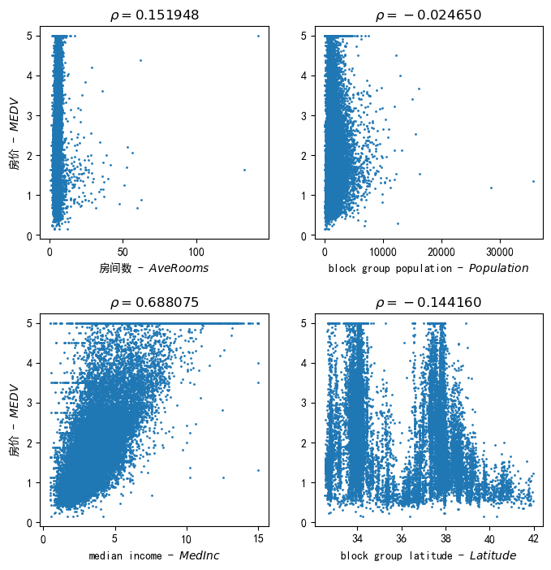

```python
fig = plt.figure( figsize=(8, 8), dpi=100 )
plt.rcParams['font.sans-serif'] = ['SimHei']
plt.rcParams['axes.unicode_minus'] = False

plt.subplots_adjust(hspace=0.35)
plt.subplot(2, 2, 1)
plt.scatter(house['AveRooms'], house['MEDV'], s=1, marker='o', label='AveRooms-MEDV')
plt.xlabel( r"房间数 - $AveRooms$" )
plt.ylabel( r"房价 - $MEDV$" )
plt.title(r"$\rho=0.151948$")

plt.subplot(2, 2, 2)
plt.scatter(house['Population'], house['MEDV'], s=1, marker='o', label='Population-MEDV')
plt.xlabel( r"block group population - $Population$" )
plt.title(r"$\rho=-0.024650$")

plt.subplot(2, 2, 3)
plt.scatter(house['MedInc'], house['MEDV'], s=1, marker='o', label='MedInc-MEDV')
plt.xlabel( r"median income - $MedInc$" )
plt.ylabel( r"房价 - $MEDV$" )
plt.title(r"$\rho=0.688075$")

plt.subplot(2, 2, 4)
plt.scatter(house['Latitude'], house['MEDV'], s=1, marker='o', label='Latitude-MEDV')
plt.xlabel( r"block group latitude - $Latitude$" )
plt.title(r"$\rho=-0.144160$")
plt.show()
```

其中：MedInc与房价相关性较大，AveRooms、Latitude与房价相关性很弱，与Population几乎无关  
我们留下edInc、AveRooms，与Population，其中Population用于对比

```python
house1 = house[['MedInc','AveRooms','Population','MEDV']]
house1.corr(method='pearson')
```

|  | MedInc | AveRooms | Population | MEDV |
| --- | --- | --- | --- | --- |
| MedInc | 1.000000 | 0.326895 | 0.004834 | 0.688075 |
| AveRooms | 0.326895 | 1.000000 | -0.072213 | 0.151948 |
| Population | 0.004834 | -0.072213 | 1.000000 | -0.024650 |
| MEDV | 0.688075 | 0.151948 | -0.024650 | 1.000000 |

### 2.2.4 非数值型特征的编码

#### （1）布尔型特征 map()

#### （2）离散型类别特征

1. 如籍贯，可以对应成1，2，3...来编码，但是这么做可能将本来“无序”的特征变成“有序”的类别
2. 可以使用独热编码，即将离散类别分解为布尔型，如籍贯，分为是否湖南、是否浙江、是否湖北...
3. Pandas提供了get_dummies(),scikit-learn中也提供了独热编码类OneHotEncoder

```python
df = pd.DataFrame({'是否第二学位':['Y','N','N','N','Y','N'],\
                   '性别':['男','男','女','女','女','男'],\
                   '籍贯':['北京','山东','北京','安徽','安徽','北京']})
df
```

|  | 是否第二学位 | 性别 | 籍贯 |
| --- | --- | --- | --- |
| 0 | Y | 男 | 北京 |
| 1 | N | 男 | 山东 |
| 2 | N | 女 | 北京 |
| 3 | N | 女 | 安徽 |
| 4 | Y | 女 | 安徽 |
| 5 | N | 男 | 北京 |

```python
df['是否第二学位'] = df['是否第二学位'].map({'N':0,'Y':1}) ## 布尔型
df['性别'] = df['性别'].map({'女':0,'男':1})
df1 = pd.get_dummies(data=df, columns=['籍贯'], prefix='籍贯') ## 独热编码
df1
```

|  | 是否第二学位 | 性别 | 籍贯_北京 | 籍贯_安徽 | 籍贯_山东 |
| --- | --- | --- | --- | --- | --- |
| 0 | 1 | 1 | True | False | False |
| 1 | 0 | 1 | False | False | True |
| 2 | 0 | 0 | True | False | False |
| 3 | 0 | 0 | False | True | False |
| 4 | 1 | 0 | False | True | False |
| 5 | 0 | 1 | True | False | False |

### 2.2.5 数值型特征的标准化

数据集不同特征值取值范围差距大，不同量纲也会影响取值范围。  
这种差异会造成特征项之间的不平等。  
为了防止这种不平等现象被带入机器学习模型，在数据预处理环节应尽量消除量纲，统一不同特征项的取值范围，这就是数据标准化。

#### （1）Min-Max标准化

1. 是按照mi = (xi-min)/(max-min)来将数据变为[0,1]之间
2. sklearn.preprocessing中的MinMaxScaler可以据此实现标准化功能。

```python
## 使用Min-Max标准化对数据进行操作
from sklearn.preprocessing import MinMaxScaler
mmScaler = MinMaxScaler()

mmScaler.fit(house1[['MedInc','AveRooms','Population']]) # 求得数据集的均值、方差、最大值、最小值的操作
print("Min=", mmScaler.data_min_, "Max=", mmScaler.data_max_)

m = mmScaler.transform(house1[['MedInc','AveRooms','Population']]) # 对数据进行归一化操作
# m = mmScaler.fit_transform(house1[['RM','LSTAT']])
house2m = pd.DataFrame(m, columns=['MedInc','AveRooms','Population'])
house2m[['MEDV']] = house1[['MEDV']]
house2m[:5]
```

```
Min= [0.4999     0.84615385 3.        ] Max= [1.50001000e+01 1.41909091e+02 3.56820000e+04]
```

|  | MedInc | AveRooms | Population | MEDV |
| --- | --- | --- | --- | --- |
| 0 | 0.539668 | 0.043512 | 0.008941 | 4.526 |
| 1 | 0.538027 | 0.038224 | 0.067210 | 3.585 |
| 2 | 0.466028 | 0.052756 | 0.013818 | 3.521 |
| 3 | 0.354699 | 0.035241 | 0.015555 | 3.413 |
| 4 | 0.230776 | 0.038534 | 0.015752 | 3.422 |

#### （2）z-score标准化

1. 将原始数据转换成z分数或者称为标准分数，zi=(xi-ui)/sigmax
2. 描述的样本特征与其均值之间的一种标准化的相对距离。
3. 若原始数据服从正态分布，则转化后的数据服从标准正态分布
4. 这个标准化对原始数据实施了“去中心化”和“归一化”两个操作。
5. sklearn.preprocessing中的StandardScaler可以据此实现标准化功能。

```python
## 使用z-score来标准化数据
from sklearn.preprocessing import StandardScaler
zScaler = StandardScaler()
zScaler.fit(house1[['MedInc','AveRooms','Population']])
print("mean=", zScaler.mean_, "variance=", zScaler.var_)

z = zScaler.transform(house1[['MedInc','AveRooms','Population']])
# z = zScaler.fit_transform(house1[['RM','LSTAT']])
house2z = pd.DataFrame(z, columns=['MedInc','AveRooms','Population'])
house2z[['MEDV']] = house1[['MEDV']]
house2z[:5]
```

```
mean= [   3.870671      5.42899974 1425.47674419] variance= [3.60914769e+00 6.12123614e+00 1.28240832e+06]
```

|  | MedInc | AveRooms | Population | MEDV |
| --- | --- | --- | --- | --- |
| 0 | 2.344766 | 0.628559 | -0.974429 | 4.526 |
| 1 | 2.332238 | 0.327041 | 0.861439 | 3.585 |
| 2 | 1.782699 | 1.155620 | -0.820777 | 3.521 |
| 3 | 0.932968 | 0.156966 | -0.766028 | 3.413 |
| 4 | -0.012881 | 0.344711 | -0.759847 | 3.422 |

#### （3）提取特征集X和目标集Y

```python
X = house2z[['MedInc','AveRooms','Population']];
X[:5]
```

|  | MedInc | AveRooms | Population |
| --- | --- | --- | --- |
| 0 | 2.344766 | 0.628559 | -0.974429 |
| 1 | 2.332238 | 0.327041 | 0.861439 |
| 2 | 1.782699 | 1.155620 | -0.820777 |
| 3 | 0.932968 | 0.156966 | -0.766028 |
| 4 | -0.012881 | 0.344711 | -0.759847 |

```python
Y = house2z['MEDV']
Y[:5]
```

```
0    4.526
1    3.585
2    3.521
3    3.413
4    3.422
Name: MEDV, dtype: float64
```

## 2.3 模型训练与评价

### 2.3.1 训练集与测试集

为了关注训练的模型是否具有预测能力，需要对数据集进行拆分

1. 训练集
2. 测试集

```python
from sklearn.model_selection import train_test_split
X_train,X_test,Y_train,Y_test = train_test_split(X, Y, test_size=0.2, random_state=2020)  # rrandom_state这个值，不同，划分的训练集和测试集也不一样
print("X_train:", X_train.shape, "Y_train:", Y_train.shape)
print("X_test:", X_test.shape, "Y_test:", Y_test.shape)
```

```
X_train: (16512, 3) Y_train: (16512,)
X_test: (4128, 3) Y_test: (4128,)
```

### 2.3.2 模型训练与梯度下降法【GD】

1. 损失函数：实际上就是模型再训练集上的目标预测值与真实值之间的误差，写成函数形式。
2. 学习算法：获取使得损失函数最小的参数的算法是学习算法，即优化算法。
3. 梯度下降算法：一种优化算法，$\omega^{k} = \omega^{k-1}-a*\nabla(\omega^{k-1})$
4. 梯度下降算法的条件：函数一阶可导
5. 梯度下降算法还有变形：随机梯度下降算法（SGD）、小批量梯度下降算法（MBGD）：算误差所用的数据点数不一样：随机一个 or 随机多个 or 全部

定理 2-1：函数$f(x_1,x_2)$在$v$方向上的方向导数为$\frac{\partial f(x_1,x_2)}{\partial v} = \frac{\partial{f}}{x_1}cos\theta + \frac{\partial{f}}{x_2}sin\theta$

使用scilit-learn中的线性回归模型以及上面生成的训练集和测试机进行回归分析

```python
from sklearn.linear_model import LinearRegression
lr = LinearRegression()
lr.fit(X_train, Y_train)
print(lr.coef_, lr.intercept_)

XY_test = X_test[:5].copy()
XY_test['MEDV'] = Y_test[:5]
XY_test['MEDV_predict'] = lr.predict(X_test[:5])
XY_test
```

```
[ 0.82378749 -0.09050685 -0.0416022 ] 2.0692748147393067
```

|  | MedInc | AveRooms | Population | MEDV | MEDV_predict |
| --- | --- | --- | --- | --- | --- |
| 6847 | 0.168193 | -0.246713 | -0.679489 | 2.350 | 2.258428 |
| 17018 | 1.583360 | 0.281395 | 0.026071 | 3.868 | 3.347074 |
| 15399 | 0.880277 | 0.731873 | 0.396953 | 2.864 | 2.711682 |
| 18714 | 0.125925 | 0.568248 | 1.545805 | 1.201 | 2.057271 |
| 1742 | -0.712858 | -0.504303 | 0.121440 | 1.142 | 1.522622 |

### 2.3.3 模型评价与k折交叉验证

需要用测试集对训练好的模型进行评价，需要有一些评价指标

#### （1）决定系数R方

1. 均方误差：残差平方的平均值，$SS_{res}$
2. 决定系数R方：$R^2 = 1-\frac{SS_{res}}{SS_{tot}}$

R方=1：预测性能达到最佳 R方=1：勉强可以接受 R方小于0：很差

```python
from sklearn.linear_model import LinearRegression
from sklearn.metrics import mean_squared_error

lr = LinearRegression()
lr.fit(X_train, Y_train);  print(lr.coef_, lr.intercept_)

print("训练集R方：%f，" % lr.score(X_train, Y_train), end='')
print("训练集MSE：%f" % mean_squared_error( Y_train, lr.predict(X_train)))

print("测试集R方：%f，" % lr.score(X_test, Y_test), end='')
print("测试集MSE：%f" % mean_squared_error( Y_test, lr.predict(X_test)))
```

```
[ 0.82378749 -0.09050685 -0.0416022 ] 2.0692748147393067
训练集R方：0.477951，训练集MSE：0.692090
测试集R方：0.490650，测试集MSE：0.690104
```

#### （2）k折交叉验证

1. 留出法：就是普通的，数据集就拆一次，分为训练集和侧式集。即训练一次、测试一次。偶然因素大
2. k折交叉验证：将数据集平均拆分为k份，获得k个互斥子集，每次用其中k-1个子集训练，剩余一个测试。

下面这个，对数据集进行了3折拆分，训练了三次，评价了3次

```python
from sklearn.linear_model import LinearRegression
from sklearn.metrics import mean_squared_error
lr = LinearRegression()

from sklearn.model_selection import KFold
kf = KFold(n_splits=3);  n = 0
for train_index, test_index in kf.split(X):
    n += 1
    print(n, "：TRAIN", train_index.shape, "  TEST", test_index.shape)
    X1_train, X1_test = X.iloc[train_index], X.iloc[test_index]
    Y1_train, Y1_test = Y.iloc[train_index], Y.iloc[test_index]

    lr.fit(X1_train, Y1_train);  print(lr.coef_, lr.intercept_)
    print("测试集R方：%f，" % lr.score(X1_test, Y1_test), end='')
    print("测试集MSE：%f" % mean_squared_error( Y1_test, lr.predict(X1_test)))
```

```
1 ：TRAIN (13760,)   TEST (6880,)
[ 0.84614305 -0.13871251 -0.06929212] 2.071999772414892
测试集R方：0.472808，测试集MSE：0.710722
2 ：TRAIN (13760,)   TEST (6880,)
[ 0.83164491 -0.10177548 -0.01244305] 2.109544947567976
测试集R方：0.490405，测试集MSE：0.608956
3 ：TRAIN (13760,)   TEST (6880,)
[ 0.80627598 -0.07055879 -0.02870123] 2.025960524034369
测试集R方：0.445361，测试集MSE：0.791452
```

下面做了3折拆分，并对3次训练的模型进行整合。实际上就是把系数的平均值作为最终系数

```python
from sklearn.linear_model import LinearRegression
from sklearn.metrics import mean_squared_error
lr = LinearRegression()
coef = [0, 0, 0];  intercept = 0

from sklearn.model_selection import KFold
kf = KFold(n_splits=3, shuffle=True, random_state=2020);  n = 0
for train_index, test_index in kf.split(X):
    n += 1
    X1_train, X1_test = X.iloc[train_index], X.iloc[test_index]
    Y1_train, Y1_test = Y.iloc[train_index], Y.iloc[test_index]
    lr.fit(X1_train, Y1_train)
    coef += lr.coef_;  intercept += lr.intercept_

lr.coef_ = coef/n;  lr.intercept_ = intercept/n
print(lr.coef_, lr.intercept_)

print("训练集R方：%f，" % lr.score(X_train, Y_train), end='')
print("训练集MSE：%f" % mean_squared_error( Y_train, lr.predict(X_train)))

print("测试集R方：%f，" % lr.score(X_test, Y_test), end='')
print("测试集MSE：%f" % mean_squared_error( Y_test, lr.predict(X_test)))
```

```
[ 0.82670408 -0.09939168 -0.03971892] 2.068544972151973
训练集R方：0.477890，训练集MSE：0.692171
测试集R方：0.491067，测试集MSE：0.689539
```

## 2.4 正则化

线性方程组:Ax=b

1. A是非奇异的（可逆）：则方程有唯一解
2. A是奇异的（不可逆、不满秩）：则有无穷多解
3. A是近似奇异的(奇异值分解后，其奇异值近似等于0)：方程的解不稳定:右边的b变动只是很微小的变动就能引起解的巨大变动

不适定问题：解不唯一或者不稳定的方程定解问题

### 2.4.1 正则化方法

为了避免训练获得的参数对训练集数据太过敏感，可以使用正则化方法

奥卡姆剃刀(Occam`s razor):无从选择时应选择简单的

正则化就是在损失函数的基础上增加一个限制参数$\omega$取值过大的项，叫做正则化项或者惩罚项

概念：

1. 损失函数
2. L1范数条件
3. L2范数条件
4. 拉格朗日乘子法将单纯的优化问题变为有约束的最优化问题

### 2.4.2 岭回归与超参数调优

1. 使用L2范数的叫做岭回归(ridge regression)
2. 使用L1范数的叫做LASSO回归(least absolute shrinkage and selection operator)

#### （1）下面使用岭回归训练模型

```python
from sklearn.linear_model import Ridge
from sklearn.metrics import mean_squared_error

rd = Ridge(alpha=1.0)    ### 疑问？？这个参数是什么意思？超参数？
rd.fit(X_train, Y_train)
print(rd.coef_, rd.intercept_)

print("训练集R方：%f，" % rd.score(X_train, Y_train), end='')
print("训练集MSE：%f" % mean_squared_error( Y_train, rd.predict(X_train)))

print("测试集R方：%f，" % rd.score(X_test, Y_test), end='')
print("测试集MSE：%f" % mean_squared_error( Y_test, rd.predict(X_test)))
```

```
[ 0.82372936 -0.09048317 -0.04159771] 2.0692748003196977
训练集R方：0.477951，训练集MSE：0.692090
测试集R方：0.490649，测试集MSE：0.690106
```

#### （2）超参数调优与k折交叉验证

也就是认为设计一个超参数候选列表，然后扫描，获得最好的那个超参数。

```
{'alpha': 83.83838383838385} 0.6942863490882912
训练集MSE：0.692111，训练集R方：0.477935
测试集MSE：0.690242，测试集R方：0.490548
```

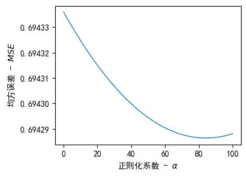

```python
from sklearn.linear_model import Ridge
from sklearn.metrics import r2_score
rd = Ridge()

from sklearn.model_selection import GridSearchCV
lamda = np.linspace(0, 100, 100)
grid = {'alpha': lamda}
gs = GridSearchCV(estimator=rd, param_grid=grid,\
                  scoring='neg_mean_squared_error', cv=3)
gs.fit(X_train, Y_train)
print(gs.best_params_, -gs.best_score_)
print("训练集MSE：%f，" % -gs.score(X_train, Y_train), end='')
print("训练集R方：%f" % r2_score( Y_train, gs.predict(X_train)))
print("测试集MSE：%f，" % -gs.score(X_test, Y_test), end='')
print("测试集R方：%f" % r2_score( Y_test, gs.predict(X_test)))

fig = plt.figure( figsize=(4, 3), dpi=100 )
plt.rcParams['font.sans-serif'] = ['SimHei']
plt.rcParams['axes.unicode_minus'] = False
plt.plot(lamda, -gs.cv_results_['mean_test_score'], linewidth=1)
# plt.text(10, 31.58, r"网格搜索：$\alpha$", fontsize=18)
plt.xlabel( r"正则化系数 - $\alpha$" )
plt.ylabel( r"均方误差 - $MSE$" )
plt.show()
```

### 2.4.3 LASSO回归与坐标下降法

使用LASSO回归类Lasso

```python
from sklearn.linear_model import Lasso
from sklearn.metrics import mean_squared_error

las = Lasso(alpha=1.0, max_iter=1000)  ### 这两个参数？？？
las.fit(X_train, Y_train)
print(las.coef_, las.intercept_)

print("训练集R方：%f，" % las.score(X_train, Y_train), end='')
print("训练集MSE：%f" % mean_squared_error( Y_train, las.predict(X_train)))

print("测试集R方：%f，" % las.score(X_test, Y_test), end='')
print("测试集MSE：%f" % mean_squared_error( Y_test, las.predict(X_test)))
```

```
[ 0.  0. -0.] 2.0691877186288754
训练集R方：0.000000，训练集MSE：1.325718
测试集R方：-0.000007，测试集MSE：1.354882
```

坐标下降算法

梯度下降算法要求描述误差的函数是一阶可导的，岭回归使用的是L2范数，是可导的。但是LASSO回归使用的是L1范数，其中包含绝对值函数，其在最小值点是不可导的，不能 采用梯度下降法优化参数。故而，使用坐标下降算法。

坐标下降算法是选取一个参数初值，对参数矢量的参数依次进行迭代。

### 2.4.5 问题：岭回归和LASSO回归的参数是什么意思？？？？

具体参见上面的代码

## 2.5 非线性回归

非线性模型(如多项式模型、指数模型、三角函数模型)，可以通过一些方法，将模型转换为线性模型来求解。

### 2.5.1 换元法

（1）多项式模型

增加特征的维度，如$x$和$x^2$看成是两个变量$x_1$和$x_2$  
不足之处是特征维度增加，导致计算量大大增加  
下面是sklearn中有专门的类来解这个问题

```python
from sklearn.linear_model import Lasso
from sklearn.metrics import mean_squared_error
from sklearn.preprocessing import PolynomialFeatures

poly = PolynomialFeatures(2, include_bias=False)
X_train_pf = poly.fit_transform(X_train)
X_test_pf = poly.fit_transform(X_test)
print("X_train：", X_train.shape, "，X_train_pf.shape：", X_train_pf.shape)

las = Lasso(alpha=1.0, max_iter=1000)
las.fit(X_train_pf, Y_train)
print(las.coef_, las.intercept_)

print("训练集R方：%f，" % las.score(X_train_pf, Y_train), end='')
print("训练集MSE：%f" % mean_squared_error(Y_train, las.predict(X_train_pf)))

print("测试集R方：%f，" % las.score(X_test_pf, Y_test), end='')
print("测试集MSE：%f" % mean_squared_error(Y_test, las.predict(X_test_pf)))
```

```
X_train： (16512, 3) ，X_train_pf.shape： (16512, 9)
[ 0.         0.        -0.         0.0178837  0.        -0.
  0.         0.        -0.       ] 2.051454257489449
训练集R方：0.028603，训练集MSE：1.287798
测试集R方：0.031181，测试集MSE：1.312626
```

（2）指数模型

$y=e^{\omega^{T}x+b}$ 变为 $y^` = ln(y) = w^{T}x+b$

从上面的描述可以看到，可以通过换因变量让模型变为线性模型，也可以换自变量的形式。

#### 2.5.2 逻辑斯谛回归

以人口问题为引入，讲了一个叫做逻辑斯谛回归的东西，实际上就是使用对数变换和换元法将非线性模型变为线性模型。

这其中涉及到了一个逻辑斯谛函数：  
$P=\frac{1}{1+e^{-z}}$  
他是一个S形函数，其中P代表概率，像这种S型函数就特别适合做分类。